# Used Vehicles Valuation

USED VEHICLES PRICE VALUATION

```python
import pandas as pd
import numpy as np
import scipy.stats as stats
from sklearn.impute import SimpleImputer
from sklearn.preprocessing import StandardScaler
from sklearn.preprocessing import OneHotEncoder
from sklearn.model_selection import train_test_split
from sklearn.linear_model import LinearRegression
from sklearn.tree import DecisionTreeRegressor
from sklearn.ensemble import RandomForestRegressor
from sklearn.neighbors import KNeighborsRegressor
from sklearn import svm
from sklearn.ensemble import GradientBoostingRegressor
import tensorflow as tf
from tensorflow import keras
from tensorflow.keras.layers import Dense
from sklearn.model_selection import RandomizedSearchCV
from sklearn.model_selection import GridSearchCV
from sklearn.metrics import mean_squared_error
from sklearn.metrics import r2_score
from sklearn.model_selection import cross_val_score
import matplotlib.pyplot as plt
import seaborn as sns
import warnings
warnings.filterwarnings('ignore')
%matplotlib inline
```

REMOVE FIRSTCASHPRICE

### 1. Analysis

1. The problem

A used vehicle marketplace in Denmark wants to automate the valuation of the used vehicles sold in their platform.

Vehicle dealers have to estimate the price of the used vehicles they sell on the digital marketplace.

The company owning this marketplace wants to offer automated vehicle valuation as a service to these customers.

2. Define the objective in business terms

The objective of the company is to provide predictions of vehicle prices to their customer, so that they do not have to make these predictions manually.

They would be satisfied with an error in the prediction that is not higher 20 % of the lower bound of the interquartile range of used vehicle prices.

3. How should you frame the problem (supervised/unsupervised etc.)?

As we are trying to predict a continuous value for the price and we have a label for the past used vehicle prices, we will frame the problem as a supervised regression problem.

4. How should performance be measured?

Performance will be measured using RMSE, which will give us a good indication of the error in DKK.

$R^2$ will also be used to have an indication of the variance explain by the model.

### 2. Get the data

The data used in this project is real data from the company's market place. They provided us with a data extract for a certain period of time. The data is confidential and must not be shared with other parties or used for other purposes than this course's project.

```python
df_raw = pd.read_csv("used_vehicles.csv")
df = df_raw.copy()
df.shape
```

```
(97581, 43)
```

There are 97581 vehicles in the dataset, 42 features and the price label. These are the following:

```python
df.columns
```

```
Index(['PERIOD_START_DATE', 'PERIOD_END_DATE', 'LISTINGTYPE', 'DAYSTOSOLD',
       'DAYSTOSOLD_USING_LIVE_DAYS', 'SOLD', 'OBJECT_ID', 'EVENTDATETIME',
       'FIRST_PUBLICATION_DATE', 'CashPrice', 'Mileage', 'PRICE_CHANGE_FLAG',
       'FIRST_AD_TYPE', 'AD_TYPE', 'PROFESSIONAL_USER_ID', 'FUEL_TYPE',
       'DELETEDDATE', 'AgeInMonths', 'MONTHNAME_FIRST_PUBLICATION_DATE',
       'POSTALCODE', 'driveWheels', 'ChassisTypeOne', 'effect', 'gearType',
       'model', 'modelYear', 'trimStyle', 'modelSeries', 'priceFromNew',
       'ROW_NUMBER_MULTIPLE_UPDATES_WITHIN_SAME_DAY', 'acceleration0To100',
       'approvedFuelEconomyMeasurementMethod', 'engineType', 'fuelEconomy',
       'height', 'length', 'numberOfDoors', 'payload', 'topSpeed',
       'totalWeight', 'weight', 'width', 'make'],
      dtype='object')
```

We asked the company if they had any suggestions as to how we could narrow down the poblem, and they suggested that we could focus on the 20 most popular makes.

Therefore, we will start selecting those makes first, so that the data exploration is restricted to them.

```python
selected_makes = df.groupby(by="make").size().sort_values(ascending=False)[:20].index.tolist()
df = df[df.make.isin(selected_makes)]
```

```python
df.shape
```

```
(92553, 43)
```

This still leaves us with 92553 vehicles, which is a good amount of instances.

### 3. Explore the data

We can start by visualizing how many vehicles there are per make.

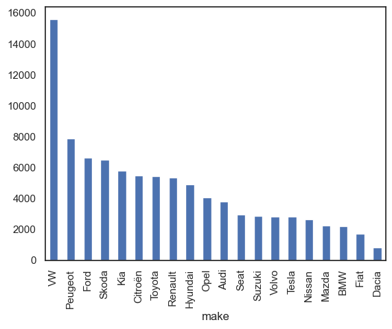

```python
df.groupby(by="make").size().sort_values(ascending=False).plot(kind='bar')
```

It seems that there are much more VW, and that in general the number of vehicles per make are not very evenly distributed.

However, we rather have as many instances as we can, instead creating a more even distribution.

From the columns we previously displayed, the following are dates that are not relevant to predict the price.

We assume they are not relevant becasue some are used to calculate DAYSTOSOLD, and others mainly give information about updates in the system.

- **PERIOD_START_DATE**: Date on which a vehicle was added to the listing as on sale.
- **PERIOD_END_DATE**: Date on which a vehicle was removed from the listing.
- **EVENTDATETIME**: Updates in the system corresponding to any kind of change in the vehicle details.
- **FIRST_PUBLICATION_DATE**: Date on which a vehicle was added to the listing.
- **DELETEDDATE**: Date on which a vehicle was removed completely from the listing.
- **MONTHNAME_FIRST_PUBLICATION_DATE**: Month in which the vehicle was published first.
- **ROW_NUMBER_MULTIPLE_UPDATES_WITHIN_SAME_DAY**: Count of times a vehicle was updated in one day.
- **DAYSTOSOLD_USING_LIVE_DAYS**: Days it took for a vehicle to be sold while it was listed.
- **PRICE_CHANGE_FLAG**: If the price was changed.

We are interested in the final price the vehicle was sold for, so we only use the final sale price.

```python
df.engineType.unique()
```

```
array([1., 3., 4., 2.])
```

The definitions for the other features are:

- **LISTINGTYPE**: The listing of a vehicle can be Standard, Plus, or Discount, depending on the choice of the user.
- **DAYSTOSOLD**: The days it took for a vehicle to sell.
- **SOLD**: True if the vehicle was sold, false if not.
- **OBJECT_ID**: the id of the vehicle in the system.
- **CashPrice**: Our label. The current price of the car, or the price the car was finally sold for.
- **Mileage**: Amount of kms travelled by the vehicle.
- **FIRST_AD_TYPE**: First type of advertisement chosen. There are three types.
- **AD_TYPE**: Advertisement type when sold.
- **PROFESSIONAL_USER_ID**: Id of the user.
- **FUEL_TYPE**: Type of fuel used by the vehicle.
- **AgeInMonths**: Age of the car in months.
- **POSTALCODE**: The postal code of the car dealer.
- **driveWheels**: Front, back or 4.
- **ChassisTypeOne**: Type of chassis. It includes many types.
- **effect**: Horse power.
- **gearType**: Manual or automatic.
- **model**: The model of the vehicle.
- **modelYear**: The year of the vehicle's model.
- **trimStyle**: Different versions of a model.
- **modelSeries**: The series of the model.
- **priceFromNew**: Market price of a new vehicle.
- **acceleration0To100**: Acceletation from 0 to 100.
- **engineType**: Type of engine. There are for options.
- **height**: The height of the vehicle.
- **length**: The length of the vehicle.
- **numberOfDoors**: The number of doors of the vehicle.
- **payload**: The load that the vehicle can carry.
- **topSpeed**: The vehicle's top speed.
- **totalWeight**: The weight of the vehicle including passengers and cargo.
- **weight**: The weight of the vehicle.
- **width**: The width of the vehicle.
- **make**: The vehicle's make (VW, Peugeot, ...)

Another feature is approvedFuelEconomyMeasurementMethod describes the method use to measure fuel economy consumption.

```python
df.approvedFuelEconomyMeasurementMethod.unique().tolist()
```

```
[0.0, 2.0, 1.0]
```

```python
df.groupby(by="approvedFuelEconomyMeasurementMethod").size()
```

```
approvedFuelEconomyMeasurementMethod
0.0    48766
1.0    17281
2.0    26506
dtype: int64
```

We can see that there are many that are 0, which means that the method was not recorded, so it counts as a null for. We will therefore, exclude it from the dataset.

Furthermore, we discovered that another feature called fuelEconomy includes different methods and therefore values in different scales for electric vehicles and gas vehicles. Because we also have the issue with approvedFuelEconomyMeasurementMethod, we will remove both columns later on.

Next, we check for nulls.

```python
df.info()
```

```
<class 'pandas.core.frame.DataFrame'>
Index: 92553 entries, 0 to 97580
Data columns (total 43 columns):
 #   Column                                       Non-Null Count  Dtype
---  ------                                       --------------  -----
 0   PERIOD_START_DATE                            92553 non-null  object
 1   PERIOD_END_DATE                              92553 non-null  object
 2   LISTINGTYPE                                  92553 non-null  object
 3   DAYSTOSOLD                                   92553 non-null  int64
 4   DAYSTOSOLD_USING_LIVE_DAYS                   92553 non-null  int64
 5   SOLD                                         92553 non-null  int64
 6   OBJECT_ID                                    92553 non-null  object
 7   EVENTDATETIME                                92553 non-null  object
 8   FIRST_PUBLICATION_DATE                       92553 non-null  object
 9   CashPrice                                    92553 non-null  int64
```

[output cut: 35 more lines]

ModelSeries has many nulls, so we will remove it.

driveWheels has few nulls, but it is categorical and we prefer to remove it.

The rest features with nulls are numerical and we will impute them later.

Now we will look at the correlations with ChashPrice.

```python
correlation_features = df[["CashPrice", "DAYSTOSOLD", "SOLD", "Mileage", "AgeInMonths", "effect", "modelYear", "priceFromNew",
                         "acceleration0To100", "height", "length", "numberOfDoors", "payload", "topSpeed", "totalWeight", "weight", "width"]]
corr_matrix = correlation_features.corr()
corr_matrix["CashPrice"].sort_values(ascending=False)
```

```
CashPrice             1.000000
priceFromNew          0.780997
weight                0.777713
totalWeight           0.761538
effect                0.724105
modelYear             0.717989
width                 0.679779
length                0.548852
topSpeed              0.362468
height                0.206751
payload               0.199075
DAYSTOSOLD            0.092678
numberOfDoors         0.040527
SOLD                 -0.114317
Mileage              -0.584641
acceleration0To100   -0.679183
AgeInMonths          -0.709687
Name: CashPrice, dtype: float64
```

payload, DAYSTOSOLD, SOLD and numberOfDoors, are not very correlated to the CashPrice. Therefore, we will remove the later on.

We can also look at how all numerical features are correlated.

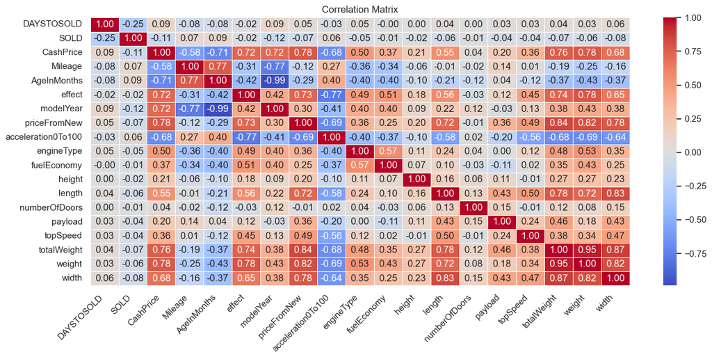

```python
numerical_features = df.select_dtypes(include="number")
numerical_features = numerical_features.drop(["ROW_NUMBER_MULTIPLE_UPDATES_WITHIN_SAME_DAY", "approvedFuelEconomyMeasurementMethod", 'DAYSTOSOLD_USING_LIVE_DAYS'], axis=1)

corr_matrix = numerical_features.corr()

sns.set(font_scale=1)
plt.figure(figsize=(15, 6))
sns.set_theme(style="white")
sns.heatmap(corr_matrix, annot=True, cmap='coolwarm', linewidths=.5, fmt=".2f")
plt.xticks(rotation=45, ha='right')
plt.title(f'Correlation Matrix')

plt.show()
```

From the diagram, we can see that there are a few features that are correlated with each other, for example, as expected, weight and total, also with width. A bit more surprising is the correlation of weight, totalWeight and width with priceFromNew. We can see that there is already a good correlation between CashPrice and priceFromNew, so we will remove totalWeight, weight and width.

The next step will be to look at the distributions of the label and priceFromNew.

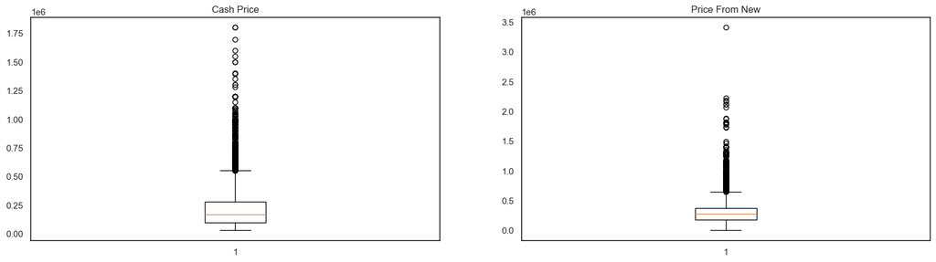

```python
figure, axis = plt.subplots(1, 2, figsize=(20, 5))
axis[0].boxplot(df.CashPrice)
axis[0].set_title("Cash Price")
axis[1].boxplot(df.priceFromNew)
axis[1].set_title("Price From New")
plt.show()
```

From the boxplots, we can see that they are skewed and that there are many outliers. We want to have as few outliers as possible for the prices.

We have also made a selection of other numerical features:

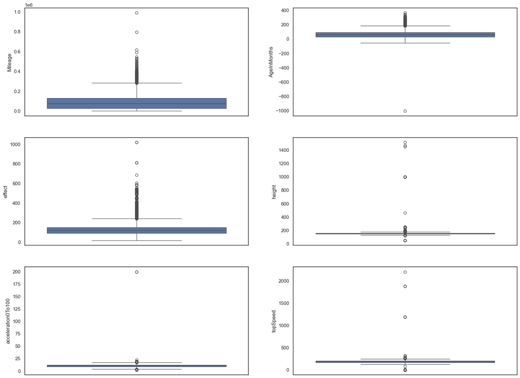

```python
figure, axis = plt.subplots(3, 2, figsize=(20, 15))
sns.boxplot(df.Mileage, ax=axis[0,0])
sns.boxplot(df.AgeInMonths, ax=axis[0,1])
sns.boxplot(df.effect, ax=axis[1,0])
sns.boxplot(df.height, ax=axis[1,1])
sns.boxplot(df.acceleration0To100, ax=axis[2,0])
sns.boxplot(df.topSpeed, ax=axis[2,1])
plt.show()
```

We don't want to remove to many vehicles from the dataset, so we will focuse on taking out those outliers that stand out the most.

For Mileage there are two outliers that stand out. We will remove these.

AgeInMonths has negative values, so we will remove them.

High horse power is a Tesla Model S and X. So we will keep it. There are other many outliers in horse power, but we would like to keep as much vehicles as possible, so we will leave it as it is.

```python
df[df["effect"]==df.effect.max()][["make", "model", "effect"]]
```

|  | make | model | effect |
| --- | --- | --- | --- |
| 6891 | Tesla | Tesla Model X | 1020 |
| 46672 | Tesla | Tesla Model S | 1020 |

The high top speeds and acceleration make no sense. So we will remove the higher ones. Some of the heights are also strange. The highest vehicle is an Opel Astra, which is not a very high car, so we will remove those.

```python
df[df["height"]==df.height.max()].model
```

```
44992    Opel Astra
Name: model, dtype: object
```

### 4. Prepare the data

In this part, we will perform the transformations needed based on out findings in the previous section.

We will start by dropping some of the features that we deemed irrelevant.

```python
df.drop(["PERIOD_START_DATE", "PERIOD_END_DATE", "EVENTDATETIME", "FIRST_PUBLICATION_DATE",
         "DELETEDDATE", "MONTHNAME_FIRST_PUBLICATION_DATE", "ROW_NUMBER_MULTIPLE_UPDATES_WITHIN_SAME_DAY",
         "DAYSTOSOLD_USING_LIVE_DAYS", "PRICE_CHANGE_FLAG", "OBJECT_ID", "PROFESSIONAL_USER_ID",
         "approvedFuelEconomyMeasurementMethod", "fuelEconomy", "modelSeries", "driveWheels",
         'SOLD', 'DAYSTOSOLD', 'numberOfDoors', 'payload', 'totalWeight', 'weight', 'width'], axis=1, inplace=True)
```

We will now remove some outliers. For the prices we want to remove as least as possible, so we will not multiple the interquartile range by 2/3.

We also remove the negative values for AgeInMonths, keep other outliers.

```python
for num_feature in ["priceFromNew", "CashPrice"]:
    q25, q75 = df[num_feature].quantile(0.25), df[num_feature].quantile(0.75)

    iqr = q75 - q25
    cut_off = iqr
    lower, upper = 0, q75 + cut_off
    if df[num_feature].isnull().sum() > 0:
        print(f"Ignored {num_feature}")
    else:
        print(f"{num_feature} has a lower = {lower} and a upper = {upper}")
        df = df.drop(df[df[num_feature] > upper].index)
        df = df.drop(df[df[num_feature] < lower].index)

df = df[df["AgeInMonths"] >= 0]
```

```
priceFromNew has a lower = 0 and a upper = 556441.0
CashPrice has a lower = 0 and a upper = 435000.0
```

We also remove some of the outliers for Mileage, height, topSpeed, acceleration0To100.

```python
df = df.drop(df[df.Mileage == df.Mileage.max()].index)
df = df.drop(df[df.Mileage == df.Mileage.max()].index)
df = df.drop(df[df.height >= 400].index)
df = df.drop(df[df.topSpeed == 0].index)
df = df.drop(df[df.topSpeed >= 1000].index)
df = df.drop(df[df.acceleration0To100 == df.acceleration0To100.max()].index)
```

```python
df.shape
```

```
(85712, 21)
```

After removing outliers we still have a decent amount of vehicles in the dataframe.

We want to rename the column for modelYear, because otherwise it will cause us problems with our function to calculate feature importances.

```python
# change the name of modelYear to make it easier in feature selection
df.rename(columns={'modelYear' : 'year'}, inplace=True)
```

For our project, we want use a sample of the data to run some of the machine learning algorithms faster. Therefore, we will select a representative sample of 10000 vehicles.

This means that we will have to transform the data again later on in other phases of our project.

```python
df_sample = df.sample(10000)
```

By taking a look at the distribution of makes, as an example, we can see that the sample is similarly distributed as entire data.

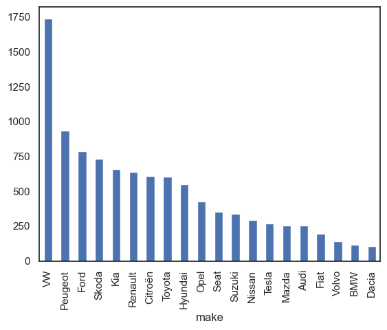

```python
df_sample.groupby(by="make").size().sort_values(ascending=False).plot(kind='bar')
```

Now we will distinguish between numerical and categorical features.

```python
num_features = ['CashPrice', 'Mileage', 'height', 'length', 'topSpeed', 'acceleration0To100', 'priceFromNew', 'AgeInMonths', "effect"]
cat_features = ['FIRST_AD_TYPE', 'AD_TYPE', 'ChassisTypeOne', 'make', 'engineType', 'trimStyle', 'FUEL_TYPE', 'gearType', 'model', 'year', 'POSTALCODE' ]
```

```python
# This function allows us to select columns and distinguish between num and cat for both the sample and entire data later on.
def num_and_cat_dfs(df, num_features, cat_features):
    df_num = df[num_features]
    df_cat = df[cat_features]
    return df_num, df_cat
```

```python
df_num_sample, df_cat_sample = num_and_cat_dfs(df_sample, num_features, cat_features)
```

We now take out the label from the numerical features.

```python
# This function allows us to separate the label from the features for both the sample and the entire data later on.
def label_and_num_features(label, df_num):
    y = df_num[label]
    X_num = df_num[df_num.columns[1:]]
    return y, X_num
```

```python
y_sample, X_num_sample = label_and_num_features("CashPrice", df_num_sample)
```

Next, we want to impute the null data from our numerical features. We will use the SimpleImputer, and use the median. (We used other imputers, but there was not a big difference in the final results.)

We also scale the data.

```python
def impute_and_scale(X_num):
    missing_columns = X_num.columns
    imputer = SimpleImputer(strategy="median")
    features_imputed = imputer.fit_transform(X_num)
    imputed_data = pd.DataFrame(features_imputed, columns=missing_columns)
    std_scale = StandardScaler(copy=True)
    features_scaled = std_scale.fit_transform(imputed_data)
    return pd.DataFrame(features_scaled, columns=missing_columns)
```

```python
scaled_sample_data = impute_and_scale(X_num_sample)
```

The categorical features have to be encoded, and for this we use OneHotEncoder.

```python
for col in df_cat_sample:
    df_cat_sample[col] = df_cat_sample[col].astype("string")
for col in df_cat_sample:
    df_cat_sample[col] = df_cat_sample[col].astype("category")
```

```python
encoder = OneHotEncoder()

X_cat_sample = encoder.fit_transform(df_cat_sample).toarray()
```

Finally, we concatenated numerical and categorical features and create training and test data that we will use in the next section.

```python
X_sample = np.concatenate((scaled_sample_data, X_cat_sample), axis=1)
# Split dataset into training set and test set
X_train_sample, X_test_sample, y_train_sample, y_test_sample = train_test_split(X_sample, y_sample, test_size=0.30, random_state=42) # 70% training and 30% test
```

### 5. Short-list promising models

As we are trying to predict a continuous value, the price in DKK, so we will use a regression model.

We will first try out the following models with their default parameters and without cross validation:

- Linear Regression
- Decision Tree Regressor
- Random Forest Regressor
- KNeighbors Regressor
- SVM
- GradientBoosting Regressor
- Neural Network

We will fit these models using the sample we generated previously of 10000 rows. We know this is not ideal, but it is a way of fitting the models faster, and it should at least give us an indication of what models performe best.

We will validate the training results against the test results to see what models perform best, using RMSE and $R^2$.

```python
def display_preliminary_scores(model, X_train, y_train, X_test, y_test):
    predict_train = model.predict(X_train)
    predict_test = model.predict(X_test)
    print(f"Train RMSE score: {np.sqrt(mean_squared_error(y_train, predict_train))}")
    print(f"Train R2 score: {r2_score(y_train,predict_train)*100}")
    print(f"Test RMSE score: {np.sqrt(mean_squared_error(y_test, predict_test))}")
    print(f"Test R2 score: {r2_score(y_test,predict_test)*100}")
```

```python
lin_reg = LinearRegression()
lin_reg.fit(X_train_sample, y_train_sample)
display_preliminary_scores(lin_reg, X_train_sample, y_train_sample, X_test_sample, y_test_sample)
```

```
Train RMSE score: 16647.8941996149
Train R2 score: 97.48575354146715
Test RMSE score: 265210288872055.0
Test R2 score: -6.649822402668155e+20
```

```python
tree_reg = DecisionTreeRegressor()
tree_reg.fit(X_train_sample, y_train_sample)
display_preliminary_scores(tree_reg, X_train_sample, y_train_sample, X_test_sample, y_test_sample)
```

```
Train RMSE score: 104.88088481701516
Train R2 score: 99.99990021117294
Test RMSE score: 25019.53125762618
Test R2 score: 94.08182712177134
```

```python
forest_reg = RandomForestRegressor()
forest_reg.fit(X_train_sample, y_train_sample)
display_preliminary_scores(forest_reg, X_train_sample, y_train_sample, X_test_sample, y_test_sample)
```

```
Train RMSE score: 6450.041341886485
Train R2 score: 99.62258928216545
Test RMSE score: 17567.896020571232
Test R2 score: 97.08211068154033
```

```python
neigh_reg = KNeighborsRegressor()
neigh_reg.fit(X_train_sample, y_train_sample)
display_preliminary_scores(neigh_reg, X_train_sample, y_train_sample, X_test_sample, y_test_sample)
```

```
Train RMSE score: 17549.279894347965
Train R2 score: 97.20611945238508
Test RMSE score: 22567.348159900695
Test R2 score: 95.18506567582207
```

```python
svm_reg = svm.SVR()
svm_reg.fit(X_train_sample, y_train_sample)
display_preliminary_scores(svm_reg, X_train_sample, y_train_sample, X_test_sample, y_test_sample)
```

```
Train RMSE score: 106617.36736938942
Train R2 score: -3.120531279964611
Test RMSE score: 104310.7237987822
Test R2 score: -2.869641759661956
```

```python
gb_reg = GradientBoostingRegressor()
gb_reg.fit(X_train_sample, y_train_sample)
display_preliminary_scores(gb_reg, X_train_sample, y_train_sample, X_test_sample, y_test_sample)
```

```
Train RMSE score: 17195.513864011496
Train R2 score: 97.31762464676429
Test RMSE score: 19615.532658952474
Test R2 score: 96.36227787659514
```

We create a simple neural network with an input and an output layer. We will have the same number of units as features in the data and the input shape will be the length of the sample.

We will use MSE for the model and the Adam optimizer. The only callback we will include is EarlyStopping.

```python
def build_model():
    model = keras.Sequential([
        Dense(X_train_sample.shape[1], activation='relu', input_shape=[len(X_train_sample[0])]),
        Dense(1)
    ])

    model.compile(optimizer=tf.keras.optimizers.Adam(),
                  loss='mse',
                  metrics='mse')
    return model

model = build_model()

my_callbacks = [
tf.keras.callbacks.EarlyStopping(patience=10, restore_best_weights=True),]

history = model.fit(X_train_sample, y_train_sample, epochs = 40, validation_split = 0.2, callbacks=[my_callbacks])
```

```python
def plot_history(df):
    plt.figure()
    plt.xlabel('Epoch')
    plt.ylabel('Mean Square Error [DKK$^2$]')
    plt.plot(df['epoch'], df['mse'], label='Train Error')
    plt.plot(df['epoch'], df['val_mse'], label = 'Val Error')
    plt.legend()
```

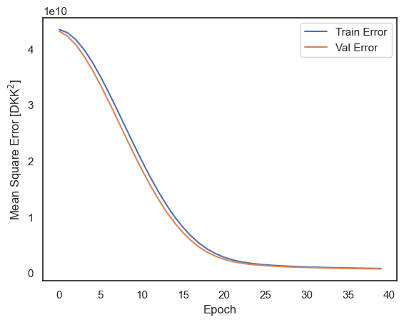

```python
hist = pd.DataFrame(history.history)
hist['epoch'] = history.epoch
plot_history(hist)
```

```python
_, mse = model.evaluate(X_train_sample, y_train_sample)
rmse = np.sqrt(mse)
print(f'Root Mean Square Error on train set: {round(rmse, 2)}')
```

```
Root Mean Square Error on train set: 28140.97
```

```python
keras_sample_predictions = model.predict(X_train_sample)
print('R2 Error on train set')
r2_score(y_train_sample, keras_sample_predictions)*100
```

```
R2 Error on train set
```

```
92.81598328708067
```

```python
_, mse = model.evaluate(X_test_sample, y_test_sample)
rmse = np.sqrt(mse)
print(f'Root Mean Square Error on test set: {round(rmse, 2)}')
```

```
Root Mean Square Error on test set: 28242.47
```

```python
keras_predictions = model.predict(X_test_sample)
print('R2 Error on test set')
r2_score(y_test_sample, keras_predictions)*100
```

```
R2 Error on test set
```

```
92.45890034391499
```

We will now select three models based on the results.

Clearly, the SVM and the Linear Regression models are missing the mark by far. So we will not move forward with these.

The Decision Tree is not performing that bad, but it is overfitting quite a lot. So we discard it.

The Random Forest is performing better, but it is also overfitting, although not as mush as the Decision Tree. It achieves better scores than the Gradient Boosting Regressor and takes around the same time to fit, although the Gradient Boosting is overfitting less. But if we can reduce overfitting, the Random Forest looks more promising. Therefore, we will pick the Random Forest, and drop Gradient Boosting.

Kneigbors does not achieve better test scores than the Gradient Boosting Regressor, or the Random Forest, but it is fast and can easily tuned. Therefore, we will give it a chance to shine.

In summary, we select:

- Random Forest Regressor
- Kneighbors Regressor
- Neural Network

Now we will perform some feature selection. We will limit ourselves to using the Random Forest for this purpose, as it is easier to extract the feature importances from it.

```python
forest_imp = forest_reg.feature_importances_
```

```python
def get_features_importance(importance, num_features, cat_columns, encoder):
    feature_names = np.concatenate((num_features, encoder.get_feature_names_out()), axis=0)
    column_names = np.concatenate((num_features, cat_columns), axis=0)
    df_tree_imp = pd.DataFrame(np.abs(importance), feature_names, columns=["coefficients"]).sort_values(by="coefficients")
    features_importance = pd.DataFrame(columns=["feature", "importance"])
    for col_name in column_names:
        filter_col = [col for col in df_tree_imp.index if col.startswith(col_name)]
        feature_importance = df_tree_imp.loc[filter_col].sum()[0]
        new_row = pd.DataFrame({"feature":[col_name], "importance":[feature_importance]})
        features_importance = pd.concat([features_importance, pd.DataFrame(new_row)],ignore_index=True, axis=0)
    return features_importance.sort_values(by="importance", ascending=False)
```

```python
forest_importances = get_features_importance(forest_imp, X_num_sample.columns, df_cat_sample.columns, encoder)
```

```python
forest_importances
```

|  | feature | importance |
| --- | --- | --- |
| 15 | gearType | 0.442007 |
| 6 | AgeInMonths | 0.298502 |
| 5 | priceFromNew | 0.171758 |
| 7 | effect | 0.022035 |
| 0 | Mileage | 0.019350 |
| 3 | topSpeed | 0.009506 |
| 4 | acceleration0To100 | 0.006855 |
| 1 | height | 0.005154 |
| 18 | POSTALCODE | 0.004613 |
| 13 | trimStyle | 0.003610 |
| 2 | length | 0.003280 |
| 16 | model | 0.002900 |
| 11 | make | 0.002473 |
| 10 | ChassisTypeOne | 0.002412 |
| 14 | FUEL_TYPE | 0.001869 |
| 17 | year | 0.001766 |
| 9 | AD_TYPE | 0.000717 |
| 8 | FIRST_AD_TYPE | 0.000674 |
| 12 | engineType | 0.000521 |

Surprisingly, the type of gear the vehicle has (manual or automatic) has a high importance, together with, the more expected, age of the vehicle. The vehicle's market price from new follows third. Fourth comes the horse power.

At the end of the list are some of the categorical features. We will remove those that have an importance than the make.

```python
df_cat_sample.drop(['ChassisTypeOne', 'year', 'FUEL_TYPE', 'AD_TYPE', 'FIRST_AD_TYPE', 'engineType'], axis=1, inplace=True)
```

Now we have to encode the categorical variables again and split in train and test.

```python
encoder = OneHotEncoder()

X_cat_sample = encoder.fit_transform(df_cat_sample).toarray()
X_sample = np.concatenate((scaled_sample_data, X_cat_sample), axis=1)
```

```python
X_train_sample, X_test_sample, y_train_sample, y_test_sample = train_test_split(X_sample, y_sample, test_size=0.30, random_state=42)
```

```python
forest_reg = RandomForestRegressor()
forest_reg.fit(X_train_sample, y_train_sample)
display_preliminary_scores(forest_reg, X_train_sample, y_train_sample, X_test_sample, y_test_sample)
```

```
Train RMSE score: 6523.270813353151
Train R2 score: 99.61397089499698
Test RMSE score: 17612.249751214633
Test R2 score: 97.06735847110095
```

```python
neigh_reg = KNeighborsRegressor()
neigh_reg.fit(X_train_sample, y_train_sample)
display_preliminary_scores(neigh_reg, X_train_sample, y_train_sample, X_test_sample, y_test_sample)
```

```
Train RMSE score: 16790.577823117175
Train R2 score: 97.44247129571215
Test RMSE score: 22139.28875915936
Test R2 score: 95.3659934955646
```

KNeighbors performs better with the changes made.

We will not run again the neural network, as removing the features does not seem to make a big differece.

### 6. Fine-tune the system

In this part of the project, we will fine-tune our model, using the sample data, and evaluate the results using the entire dataset.

First we will fine-tune the Random Forest, then the KNeighbors, and finally the Neural Network.

First we tune the hyperparameter of the Random Forest. To find the best combination we used RandomSearchCV. We included many variations for the parameters, and it took a lot of time to run. Therefore, here we have used some of the conclusions that we came to after a process of research and of running RandomSearchCV several times. We first used the entire training set to find hyperparamters. Later on we decided to use a sample of this data, because it was taking too long to find the right hyperparameters, and we did not find great differences between using all the data and a sample of it.

The hyperparameters that we considered are:

- max_depth: represents the maximum level of each tree in the random forest. It can help reduce overfitting. But we realized that this parameter was hard to play around with, and other parameters, like min_samples_split and min_samples_leaf, aftected the max_depth paramter. After doing some iterations and research, we decided to keep its default value, which is None.
- max_features: represents the maximum number of features that the random forest is allowed to try at each split. It was also hard to try different values for this parameter, as the higher the values, the longer it takes to fit the model and validate the model. We did some research and the recommended value for this parameter is [n_features/3](https://stats.stackexchange.com/questions/324370/references-on-number-of-features-to-use-in-random-forest-regression).
- n_estimators: represents the number of decision trees in the forest. We tried several values for this parameter (from 10 to 300), however, it took a lot of time for RandomSearchCV to run. After some research we can accross this [source](https://stats.stackexchange.com/questions/348245/do-we-have-to-tune-the-number-of-trees-in-a-random-forest/) which claims that (in summary) it is important to have a large enough number of estimators, but, once a this large enough number has been arrived to, most of the variations in the results will be noise. Therfore, after some iterations we went for 100.
- min_samples_leaf: represents the minimum number of samples required to be at a leaft node of each tree. Here we try several values for min_samples_leaf that we narrowed down after trying some larger ranges of values.
- min_samples_split: represents the minimum number of samples required to split an internal node of each tree. We did the same for this parameter as with min_samples_split.

```python
# Calculate the value for max_features.
max_f = X_sample.shape[1]//3
```

```python
# Create a dictionary with the hyperparameters selected, as explained above.
parameters ={'n_estimators':[100],
              'max_features':[max_f],
              'criterion':['squared_error'],
              'min_samples_leaf':np.arange(10, 51, 10),
              'min_samples_split':np.arange(10, 51, 10)
         }
```

```python
# Use RandomForestRegressor to find the best possible model from the selected parameters.
rf = RandomForestRegressor()
rf_random = RandomizedSearchCV(rf, parameters, n_iter=100, scoring='neg_mean_squared_error', n_jobs=-1, cv=3)
model_random = rf_random.fit(X_train_sample,y_train_sample)
```

```python
print(f"Best hyperparameters are: {model_random.best_params_}")
print(f"Best score is: {model_random.best_score_}")
```

```
Best hyperparameters are: {'n_estimators': 100, 'min_samples_split': 20, 'min_samples_leaf': 10, 'max_features': 427, 'criterion': 'squared_error'}
Best score is: -443132618.8785084
```

```python
# Get the best parameters.
best_min_samples_split = model_random.best_params_.get('min_samples_split')
best_min_samples_leaf = model_random.best_params_.get('min_samples_leaf')
```

```python
# Now we want to try on the entire dataset, so we select the right features, impute, scale, encode and split into train and test sets.
num_features = ['CashPrice', 'Mileage', 'height', 'length', 'topSpeed', 'acceleration0To100', 'priceFromNew', 'AgeInMonths', "effect"]
cat_features = ['make', 'trimStyle', 'gearType', 'model', 'POSTALCODE' ]
df_num, df_cat = num_and_cat_dfs(df, num_features, cat_features)
y, X_num = label_and_num_features("CashPrice", df_num)
scaled_data = impute_and_scale(X_num)
scaled_data = impute_and_scale(X_num)
for col in df_cat:
    df_cat[col] = df_cat[col].astype("string")
for col in df_cat:
    df_cat[col] = df_cat[col].astype("category")
encoder = OneHotEncoder()
X_cat = encoder.fit_transform(df_cat).toarray()
X = np.concatenate((scaled_data, X_cat), axis=1)
X_train, X_test, y_train, y_test = train_test_split(X, y, test_size=0.30, random_state=42)
```

```python
# Build a model using the best parameters and fit it to the train data.
forest_reg = RandomForestRegressor(n_estimators=100, criterion='squared_error', max_depth=None, min_samples_leaf=best_min_samples_leaf, min_samples_split=best_min_samples_split, max_features=max_f)
forest_reg = forest_reg.fit(X_train, y_train)
```

Now we can train and test. We will also cross-validate to get an average estimate for RMSE and $R^2$.

```python
# Function to cross-validate models
def display_scores(test_scores, train_scores, decimal_precision):
    test_scores = np.round(np.sqrt(test_scores), decimal_precision)
    train_scores = np.round(np.sqrt(train_scores), decimal_precision)
    print("Val Scores:", list(test_scores))
    print("Mean Val Scores:", test_scores.mean())
    print("Standard deviation Val Scores:", np.round(test_scores.std(), decimal_precision))
    print("Training Scores:", list(train_scores))
    print("Mean Training Scores:", np.round(train_scores.mean(), decimal_precision))
    print("Standard deviation Training Scores:", np.round(train_scores.std(), decimal_precision))
```

```python
# Function to display scores for training and testing
def display_scores(scores):
    print("Cross Val Scores:", scores)
    print("Mean:", scores.mean())
    print("Standard deviation:", scores.std())
```

```python
# Evaluate Random Forest
forest_train_predictions = forest_reg.predict(X_train)
forest_mse = mean_squared_error(y_train, forest_train_predictions)
forest_rmse = np.sqrt(forest_mse)
print("Training RMSE: ", forest_rmse)
r2 = r2_score(y_train, forest_train_predictions)*100
print("Training R2: ", r2)
print("------------------------")
print("Cross Validation RMSE Scores")
forest_mse_scores = cross_val_score(forest_reg, X_train, y_train, scoring="neg_mean_squared_error", cv=3)
forest_rmse_scores = np.sqrt(-forest_mse_scores)
display_scores(forest_rmse_scores)
print("------------------------")
print("Cross Validation R2 Scores")
forest_r2_scores = cross_val_score(forest_reg, X_train, y_train, scoring="r2", cv=3)
display_scores(forest_r2_scores)
```

```
Training RMSE:  13306.499257970972
Training R2:  98.41333444031714
------------------------
Cross Validation RMSE Scores
Cross Val Scores: [15505.75925618 15428.83075678 16132.11684281]
Mean: 15688.902285255383
Standard deviation: 314.96968798627836
------------------------
Cross Validation R2 Scores
Cross Val Scores: [0.97820163 0.97842699 0.97653409]
Mean: 0.9777209051394914
Standard deviation: 0.0008442325099425873
```

```python
# Function to evaluate model with test data.
def evaluate(model, X_test, y_test):
    predictions = model.predict(X_test)
    rmse = np.sqrt(mean_squared_error(y_test, predictions))
    r2 = r2_score(y_test, predictions)*100
    print("Test RMSE: ", rmse)
    print("Test R2: ", r2)
    confidence = 0.95
    squared_errors = (predictions - y_test) ** 2
    interval = np.sqrt(stats.t.interval(confidence, len(squared_errors) - 1, loc=squared_errors.mean(), scale=stats.sem(squared_errors)))
    print("95% confidence interval: ", interval)
    percentage_of_quantile = interval / df.CashPrice.quantile(0.25) * 100
    print(f"Interval for percentages of lower bound of interquartile range: {np.round(percentage_of_quantile, 2)}%")
```

```python
evaluate(forest_reg, X_test, y_test)
```

```
Test RMSE:  14672.621126906979
Test R2:  98.04112047998008
95% confidence interval:  [14364.92169543 14973.99900333]
Interval for percentages of lower bound of interquartile range: [15.98 16.66]%
```

I looks like the model is still overfitting, but much less than before. The standard deviation between RMSE scores and $R^2$ scores is small which is good. The is RMSE would be enough to satisfy the company's requirement.

Secondly, we look into the KNeighborsRegressor. It has one hyperparameter, which is the number of neighbors. The default number of neighbors is five, and now we would like to try some different values.

We can use cross-validation to do this, and create a function where we pass a range of k neighbors. Then we plot the mse for each k.

We will go up to 50 ks and see what happens with our sample data. The result will be used to narrow down or search and run it again with the entire data.

```python
def get_cv_sample_error(k):
  # calculate errors from cross-validation
  cv_errs = -cross_val_score(KNeighborsRegressor(n_neighbors=k), X=X_train_sample, y=y_train_sample,
                             scoring="neg_mean_squared_error", cv=3)
  # calculate average of the cross-validation errors
  return cv_errs.mean()
```

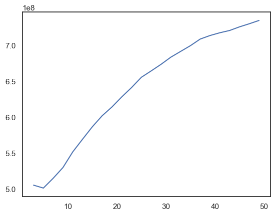

```python
ks = pd.Series(range(3, 51, 2))
ks.index = range(3, 51, 2)
test_errs = ks.apply(get_cv_sample_error)
test_errs.plot.line()
```

It seems clear that the best k is an integer which less than 10.

We now try with the entire dataset.

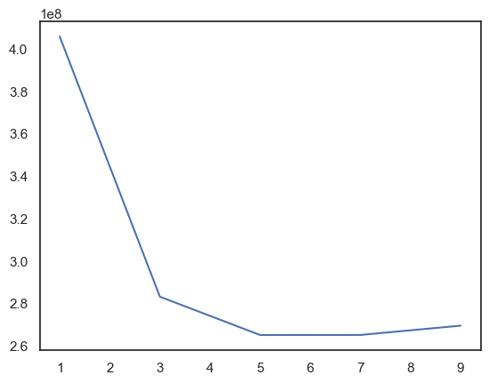

```python
def get_cv_error(k):
  # calculate errors from cross-validation
  cv_errs = -cross_val_score(KNeighborsRegressor(n_neighbors=k), X=X_train, y=y_train,
                             scoring="neg_mean_squared_error", cv=3)
  # calculate average of the cross-validation errors
  return cv_errs.mean()

ks = pd.Series(range(1, 11, 2))
ks.index = range(1, 11, 2)
test_errs = ks.apply(get_cv_error)
test_errs.plot.line()
```

It seems to be wither 5 or 7. This is not great, as the first time we fitted the model it was with k = 5.

We will run a GridSearchCV to confirm if 5 or 7 is better.

```python
from sklearn.neighbors import KNeighborsRegressor

grid_search = GridSearchCV(KNeighborsRegressor(),
                           param_grid={
                               "n_neighbors": range(3, 10, 2)
                           },
                           scoring="neg_mean_squared_error",
                           cv=3)
grid_search.fit(X_train, y_train)
grid_search.best_estimator_
```

```
KNeighborsRegressor()
```

```python
k = grid_search.best_params_.get('n_neighbors')
print("The best k is: ", k)
```

```
The best k is:  5
```

```python
neigh_reg = KNeighborsRegressor(n_neighbors=k)
neigh_reg.fit(X_train, y_train)
```

```
KNeighborsRegressor()
```

Let's see how KNeighbors perform on the entire dataset.

```python
neigh_train_predictions = neigh_reg.predict(X_train)
neigh_mse = mean_squared_error(y_train, neigh_train_predictions)
neigh_rmse = np.sqrt(neigh_mse)
print("Training RMSE: ", neigh_rmse)
r2 = r2_score(y_train, neigh_train_predictions)*100
print("Training R2: ", r2)
print("------------------------")
print("Cross Validation RMSE Scores")
neigh_mse_scores = cross_val_score(neigh_reg, X_train, y_train, scoring="neg_mean_squared_error", cv=3)
neigh_rmse_scores = np.sqrt(-neigh_mse_scores)
display_scores(neigh_rmse_scores)
print("------------------------")
print("Cross Validation R2 Scores")
neigh_r2_scores = cross_val_score(neigh_reg, X_train, y_train, scoring="r2", cv=3)
display_scores(neigh_r2_scores)
```

```
Training RMSE:  12762.407054327436
Training R2:  98.54043664418967
------------------------
Cross Validation RMSE Scores
Cross Val Scores: [16021.73280264 16393.12189584 16412.60990134]
Mean: 16275.821533274697
Standard deviation: 179.84392838641722
------------------------
Cross Validation R2 Scores
Cross Val Scores: [0.97698081 0.97585078 0.97593806]
Mean: 0.9762565501370662
Standard deviation: 0.0005133649077300557
```

```python
evaluate(neigh_reg, X_test, y_test)
```

```
Test RMSE:  15481.631134300194
Test R2:  97.81915022731519
95% confidence interval:  [15212.72971781 15745.94105444]
Interval for percentages of lower bound of interquartile range: [16.92 17.51]%
```

The results for the Kneighbors are slightly worse than the Random Forest Regressor's results. The standar deviation is also low in the cross-validation, and it looks like the model is slightly mode overfitted than the Forest.

It would still satisfy the company's requirement.

Finally, we will tune the Neural Network. To do this, we will use [KerasTuner](https://keras.io/keras_tuner/%5D). As the neural network seemed to be going in the right direction when we first tried it, we will keep the input layer with its number of units and input shape.

We would like to see if we can make it reach a lower mse value faster and if we can at the same time reduce overfitting.

- lambda or the regularization hyperparameter: adds a penalty to the loss function helping avoid overfitting.
- learning rate: how fast the neural network learns or tries to reach local minima.

We will build the model using KerasTuner's hp, standing for hyperparamenters, and run a RandomSearch. First, we will use the sample data, and then we will get the best parameters and fit a new model with them.

```python
import keras_tuner
```

```python
def build_sample_model(hp):
    model = keras.Sequential()
    model.add(Dense(X_train_sample.shape[1], activation='relu', input_shape=[len(X_train_sample[0])],
                    kernel_regularizer=tf.keras.regularizers.l2(hp.Float("regularizer", min_value=0.001, max_value=0.1, sampling="log"))))
    model.add(Dense(1))
    optimizer = tf.keras.optimizers.Adam(learning_rate=hp.Float("learning_rate", min_value=0.001, max_value=0.1, sampling="log"))
    model.compile(optimizer=optimizer, loss="mse", metrics='mse')
    return model
```

```python
tuner = keras_tuner.RandomSearch(
    hypermodel=build_sample_model,
    objective="val_mse",
    max_trials=10,
    executions_per_trial=1,
    overwrite=True,
)
```

```python
tuner.search(X_train_sample, y_train_sample, epochs=10, validation_split=0.2)
```

```
Trial 10 Complete [00h 00m 34s]
val_mse: 375628064.0

Best val_mse So Far: 294203968.0
Total elapsed time: 00h 05m 58s
```

```python
def build_model(n_units, shape, hp):
    model = keras.Sequential()
    model.add(Dense(n_units, activation='relu', input_shape=[shape],
                    kernel_regularizer=tf.keras.regularizers.l2(hp.Float("regularizer", min_value=0.001, max_value=0.1, sampling="log"))))
    model.add(Dense(1))
    optimizer = tf.keras.optimizers.Adam(learning_rate=hp.Float("learning_rate", min_value=0.001, max_value=0.1, sampling="log"))
    model.compile(optimizer=optimizer, loss="mse", metrics='mse')
    return model
```

```python
best_hps = tuner.get_best_hyperparameters()
print(best_hps[0].get("regularizer"))
print(best_hps[0].get("learning_rate"))
```

```
0.01155319199664214
0.08540133446698876
```

```python
tuned_model = build_model(X_train.shape[1], len(X_train[0]), best_hps[0])
my_callbacks = [tf.keras.callbacks.EarlyStopping(patience=10, restore_best_weights=True),]
history = tuned_model.fit(X_train, y_train, epochs=10, validation_split=0.2, callbacks=[my_callbacks])
```

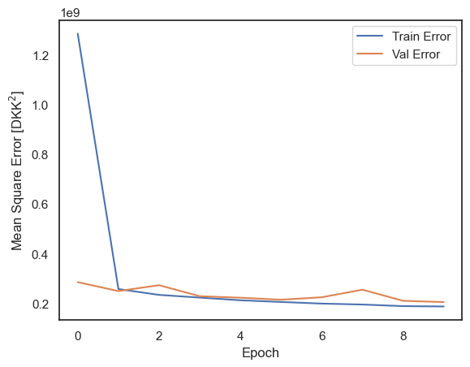

```python
hist = pd.DataFrame(history.history)
hist['epoch'] = history.epoch
plot_history(hist)
```

```python
_, mse = tuned_model.evaluate(X_train, y_train)
rmse = np.sqrt(mse)
print(f'Root Mean Square Error on train set: {round(rmse, 2)}')
```

```
Root Mean Square Error on train set: 13208.71
```

```python
keras_train_predictions = tuned_model.predict(X_train)
print('R2 Error on train set')
r2_score(y_train, keras_train_predictions)*100
```

```
R2 Error on train set
```

```
98.43656888039247
```

```python
_, mse = tuned_model.evaluate(X_test, y_test)
rmse = np.sqrt(mse)
print(f'Root Mean Square Error on test set: {round(rmse, 2)}')
```

```
Root Mean Square Error on test set: 14070.53
```

```python
keras_test_predictions = tuned_model.predict(X_test)
print('R2 Error on test set')
r2_score(y_test, keras_test_predictions)*100
```

```
R2 Error on test set
```

```
98.19858773289205
```

```python
confidence = 0.95
squared_errors = (np.rint(keras_test_predictions).astype(int).flatten() - y_test) ** 2
interval = np.sqrt(stats.t.interval(confidence, len(squared_errors) - 1, loc=squared_errors.mean(), scale=stats.sem(squared_errors)))
print("95% confidence interval: ", interval)
percentage_of_quantile = interval / df.CashPrice.quantile(0.25) * 100
print(f"Interval for percentages of lower bound of interquartile range: {np.round(percentage_of_quantile, 2)}%")
```

```
95% confidence interval:  [13783.09434541 14352.21017864]
Interval for percentages of lower bound of interquartile range: [15.33 15.96]%
```

The neural network achieves a better result than the previous models. It takes longer time to fit the model, but it is overfitting the data less than the other models.

The company did not mention any time requirements, therefore we would recommend using a neural network for the valuation of used vehicles.